# Первый этап Индивидуального проекта

Операционные системы - Бекауов А.Т

Российский университет дружбы народов, Москва, Россия

# Введение

## Цель работы

Целью данной работы является обучение размещению сайтов на Github pages. Выполнить первый этап индивидуального проекта.

# Выполнение лабораторной работы

## Скачивание архива hugo

Сначала скачивая актуальную версию hugo для своей ОС и архитектуры процессора.

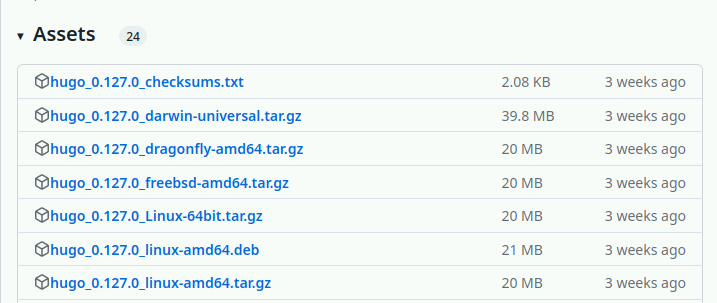

## Подготовка hugo

Распаковываю скачанный архив и перемещаю исполняемый файл hugo в созданную папку ~/bin.

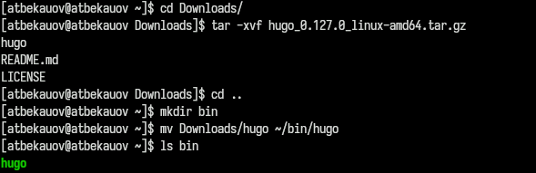

## Репозиторий - шаблон

Заходим на репозиторий GH с шаблоном сайта

[figure not shown]

## Создание репозитрия по шаблону

Создаю свой репозиторий Ind_project по этому шаблону.

[figure not shown]

## Клонирование репозитория

Клонирую созданный репозиторий в свой локальный

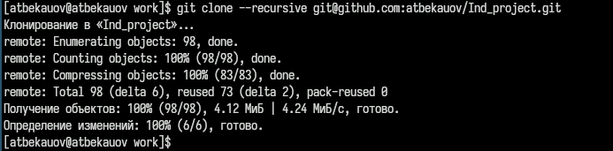

## Запуск исполняемого файла hugo

Захожу в клонированный репозиторий и запускаю исполняемый файл hugo.

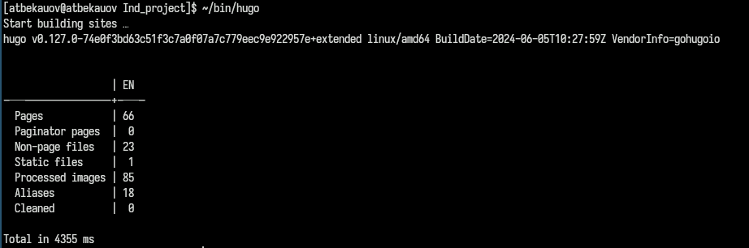

## Сайт на локальном сервере

Ввожу в репозитории Ind_project команду /~/bin/hugo server. Нажимаю на появившуся ссылку и в браузере открывается сайт на локальном сервере.

[figure not shown]

## Создание пустого репозитория

Создаю новый пустой репозиторий, имя которого будет адресом сайта.

[figure not shown]

Клонирую пустой репозиторий в локальную директорию.

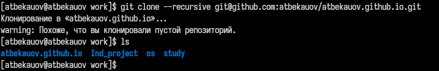

## Активация нового репозитория

Создаю главную ветку в пустом репозитории и добавляю в него пустой файл README.md. Далее составляю коммит и отправляю его на глобальный репозиторий, чтобы его активировать.

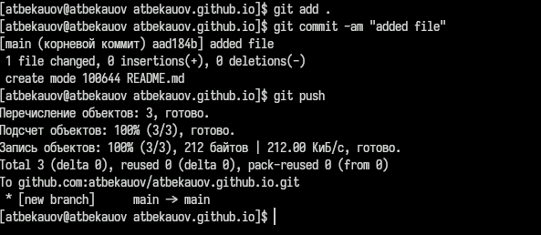

## Подключение репозитория к каталогу

Далее захожу в репозиторий Ind_project, удаляю папку public и подключаю репозиторий к каталогу public (автоматически создан)

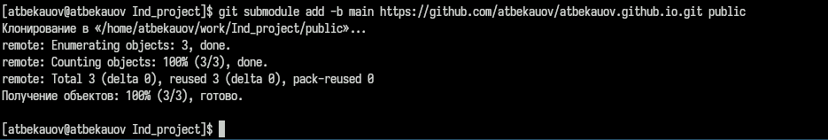

## Использование hugo

Опять выполняю команду ~/bin/hugo, чтобы наполнить каталог public.

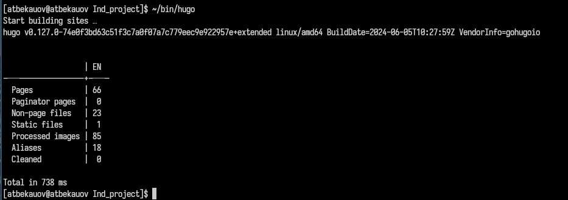

## Наполнение сайта

Захожу в каталог public и отправляю все изменения на репозиторий atbekauov.github.io

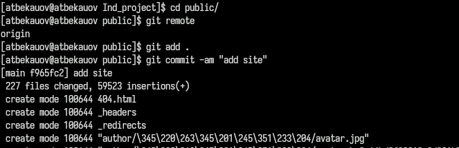

## Переход на сайт

Дальше вбиваем название репозитория atbekauov.github.io в браузере и переходим на созданный сайт

[figure not shown]

# Заключение

## Выводы

В ходе данной лаботраторной работы я научился размещать сайт на GH pages и выполнил первый этап индивидуального проекта.